# Preparación de los datos

### Estudiante

- Brian Durán

### Breve introducción a ggpairs

`ggpairs()` es una función de la librería GGally que permite crear matrices de gráficos y es realmente útil en la etapa de análisis y exploración de los datos. Pueden encontrar más información sobre `ggpairs()` y GGally en el siguiente enlace https://ggobi.github.io/ggally/#ggally

El siguiente ejemplo muestra el gráfico de las correlaciones y densidades de algunos atributos del dataset de ventas de casas.

```r
library(GGally)
```

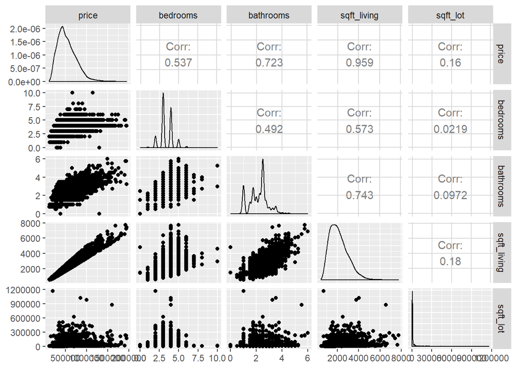

```r
library(ggplot2)

casas <- read.csv('kc_house_data.csv', header = T, na.strings = '?')
ggpairs(casas, columns = 3:7)
```

# Limpieza y transformación de los datos

A continuación utilizando el dataset de venta de casas veremos algunas funcionalidades de R para la transformación de datos.

### Detección de valores faltantes y transformaciones

La función `is.na` nos permite detectar los valores faltantes en un dataset.

El siguiente código muestra el número de elementos faltantes en todo un dataset

`sum(is.na(dataset))`

También podemos buscar valores faltantes en columnas especificas

`sum(is.na(dataset$columna))`

R posee funciones para modificar dataframes las cuales podemos aprovechar para el tratamiento de valores faltantes y transformaciones

Podemos asignar valores nuevos a toda una columna.

`dataframe$columna <- 0`

`dataframe$columna <- funcion(dataframe$columna)`

O podemos hacerlo solo en los campos faltantes.

`dataframe$columna[is.na(dataframe$columna)] <- 0`

`dataframe$columna[is.na(dataframe$columna)] <- funcion(dataframe$columna)`

# Ejercicios sobre transformaciones

### 1. Correción de valores inconsistentes

```r
casas$bathrooms[1:10]
```

```
##  [1] 2.25 1.00 4.50 1.50 1.00 1.75 2.00 3.00 2.00 1.75
```

Como podemos observar la columna bathrooms posee valores inconsistentes ya que no tiene sentido que una casa tenga 4.5 baños.

Modifique la columna bathrooms para que solo posea valores enteros

```r
head(casas$bathrooms)
```

```
## [1] 2.25 1.00 4.50 1.50 1.00 1.75
```

```r
casas$bathrooms <- as.integer(casas$bathrooms)
head(casas$bathrooms)
```

```
## [1] 2 1 4 1 1 1
```

### 2. Llevar los datos a distribución normal.

Modifique la columna price del dataset de precios de casas para que siga una distribución normal. Pista: utilice la función `log10`

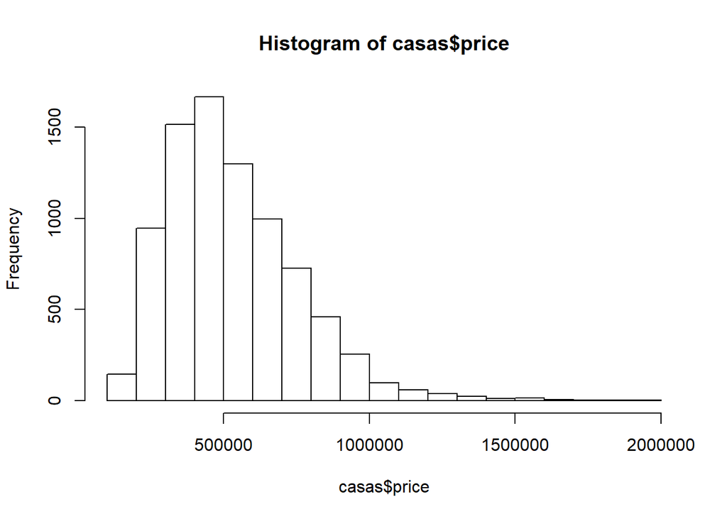

```r
# Precios antes de la modificación
hist(casas$price)
```

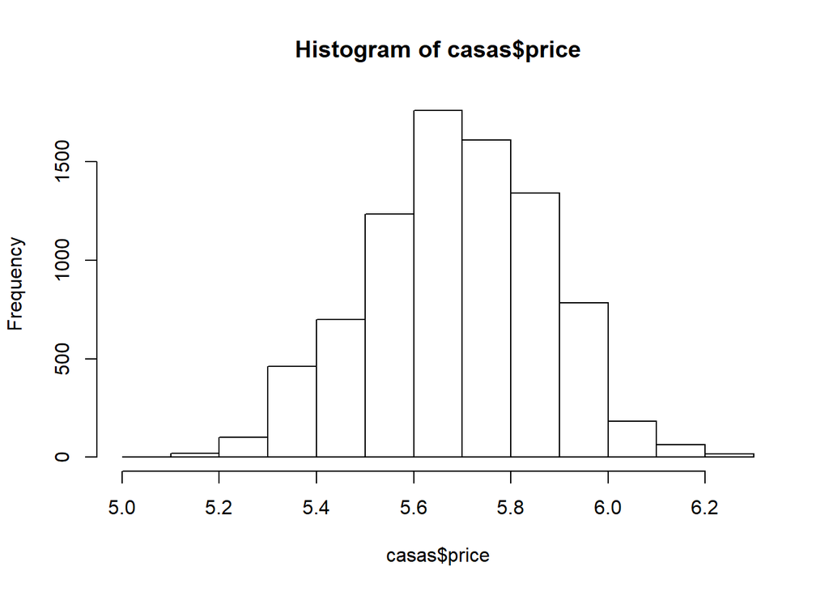

```r
casas$price <- log10(casas$price)

# Precios normalmente distribuidos
hist(casas$price)
```

Note que ahora los precios ya no se agrupan a la izquierda.

### 3. Imputar datos faltantes

Reemplace los valores faltantes de la columna sqft_living con la mediana de los valores de esa columna. Pista use la función `median`.

Nota: este dataset no posee valores faltantes pero para efectos del ejercicio esto no nos afecta ya que el código sería igual.

```r
mediana <- median(casas$sqft_living)
casas$sqft_living[is.na(casas$sqft_living)] <- mediana
```

### 4. Escalado

Un proceso común en esta etapa es escalar los atributos para que los valores queden en el rango de 0-1.

La siguiente función realiza el escalado de valores

```r
feature_scaling <- function(x) {
  x_escalado <- ((x - min(x)) / (max(x) - min(x)))
  return(x_escalado)
}
```

1. Utilice la función `feature_scaling` para escalar los valores de la columna sqft_lot

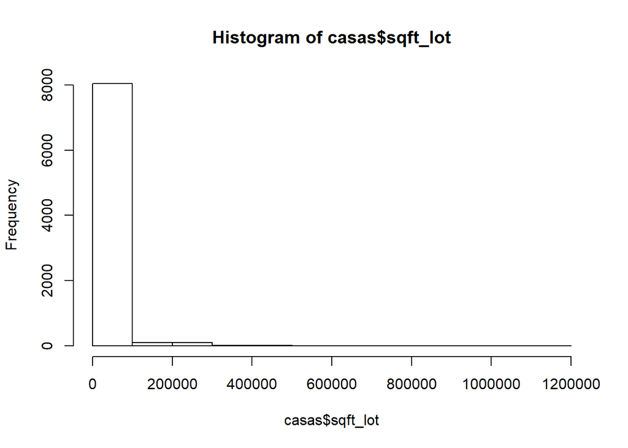

```r
hist(casas$sqft_lot)
```

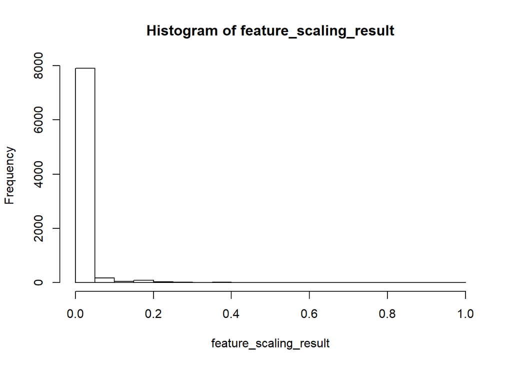

```r
feature_scaling_result <- feature_scaling(casas$sqft_lot)
hist(feature_scaling_result)
```

2. Compare el resultado con la función `scale()`

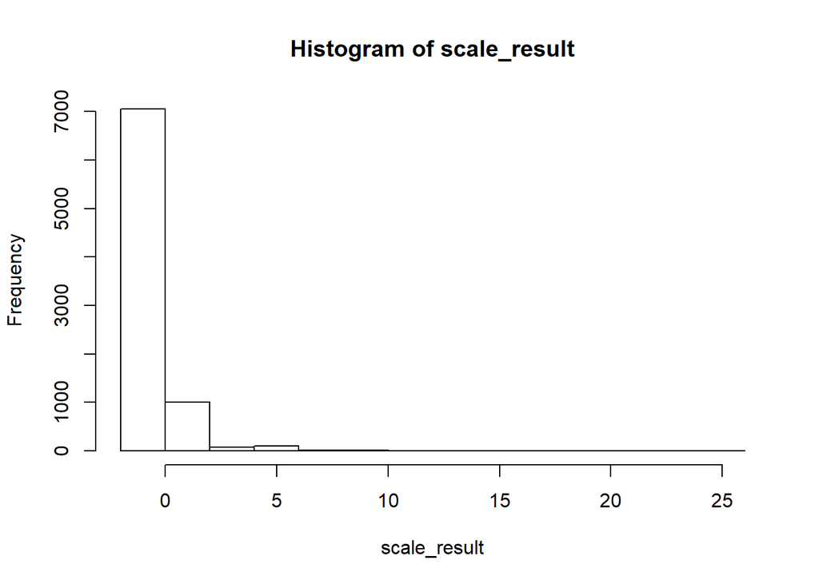

```r
scale_result <- scale(casas$sqft_lot)
hist(scale_result)
```

Se puede apreciar que los datos en el eje $x$ varian en cada función, utilizando `feature_scaling` cada rango aumenta $0.2$, mientras que usando `scale` aumentan en multiplos de $5$. Además mientras que `feature_scaling` muestra un rango de 0 a 1, `scale` presenta números negativos en el gráfico.

Por último la función `feature_scaling` utiliza el método de normalización de **mínimos y máximos** (*min-max normalization*) mientras que `scale`, de acuerdo con la documentación, utiliza una variación de la **normalización de la media** (*Mean normalization*) llamado **estandarización** (*standardization*).

### 5. Normalización con la función z-score

Otra función utilizada para transformar atributos se llama z-score y consiste en restar la media de los datos y dividir por la desviación estandar.

Escriba la función z_score y utilicela sobre la columna bathrooms.

Pista: utilice las funciones `mean`, `sd`

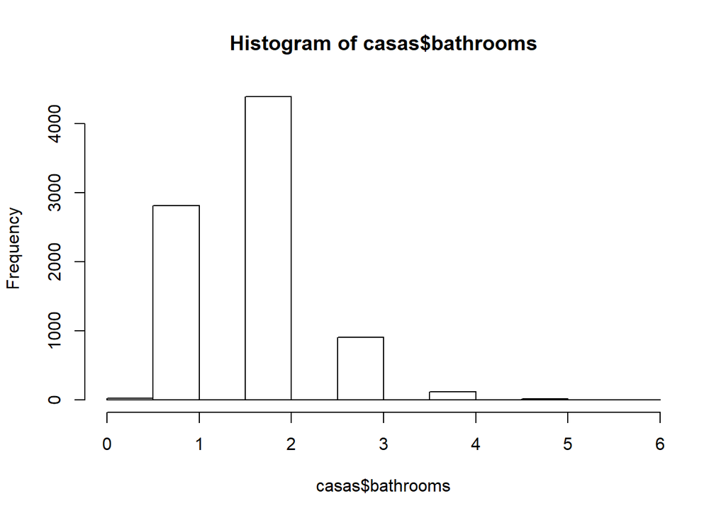

```r
# Datos antes de la transformación
hist(casas$bathrooms)
```

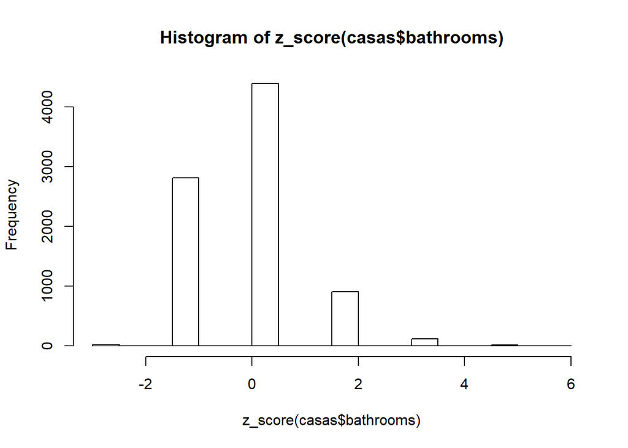

```r
z_score <- function(x) {
  media <- mean(x)
  desviacion_estandar <- sd(x)
  return((x - media) / desviacion_estandar)
}

# Después de la transformación
hist(z_score(casas$bathrooms))
```

Note que ahora la media de los datos se acerca a 0